# CSC 578B Assignment 1

Derek Robinson

Date: 2021-10-05 14:12:42

First we load our dataset and clean it up a little

```r
#load the data
df <- read.csv('data.csv')
# Clean up an entry which had "0T" instead of "OT"
df["technique"][df["technique"] == "0T"] <- "OT"
# convert category and technique (factor) to numeric
df$category <- as.factor(df$category)
df$technique <- as.factor(df$technique)
# Take a peak at the data
head(df)
```

```
##   subject category technique tp
## 1       1       LE        NT  5
## 2       1       LE        OT  6
## 3       2       LE        NT  3
## 4       2       LE        OT  3
## 5       3       LE        NT  7
## 6       3       LE        OT  3
```

## Step 1: Data Description and Descriptive Statistics

In the following table are the descriptions of each column in the dataset:

| Column Name | Description |
| --- | --- |
| Subject | A unique indentifier for each subject (participant) of the study |
| Category | Describes if the subject was more experience (ME) or less experienced (LE) |
| Technique | Which technique was being used, either new technique (NT) or old technique (OT) |
| tp (True Positives) | The number of faults classified as true faults found by the subject |

The most basic descriptive statistics are the mean and the variance. We will calculate both the mean and the variance of the true positives (`tp`).

The mean of the true positives is equal to 4.7785714 and the variance of the true positives is equal to 4.0873073.

## Step 2: A Defense of the likelihoods

First we have to decide on a likelihood for `tp`. Since `tp` takes on positive natural numbers ($\mathbb{N}^+$), we will use the $\mathsf{Poisson}(\lambda)$ distribution as this is a commonly used likelihood for this kind of data.

We will create a series of models $\mathbf{M}=\{\mathcal{M}_0,\ldots,\mathcal{M}_n\}$ and see how well the compare. After we have compared them we will choose our final model.

Before we start creating models we need to choose our prior for the lambda parameter of the poisson function. We already know the mean and variance of `tp`, so lets use those to choose a prior. We can guess that the tp should probably be below 10 most of time. First we will take a look at the default prior $\mathsf{Normal}(0,10)$.

```r
max(rnorm(70, 0, 10))
```

```
## [1] 25.81959
```

That seems a little high, lets try $\mathsf{Normal}(0,2.5)$

```r
max(rnorm(70, 0, 2.5))
```

```
## [1] 6.114207
```

That looks pretty good. Lets now make our first model which contains no predictor variables.

### Model 0

```r
m0 <- ulam(
  alist(
    tp ~ poisson(lambda),
    log(lambda) <- alpha, # log link
    alpha ~ normal(0, 2.5)
  ), data = df, cores = 2, chains = 4, cmdstan = TRUE, log_lik = TRUE, iter = 5e3
)
```

and lets check the diagnostics for model 0

```r
precis(m0)
```

```
##           mean         sd     5.5%    94.5%    n_eff    Rhat4
## alpha 1.563181 0.03836779 1.500848 1.625693 3217.161 1.001416
```

Okay, so `n_eff` is in the thousands and $\widehat{R} < 1.01$, that’s good.

Let’s also have a look at the trankplots for model 0.

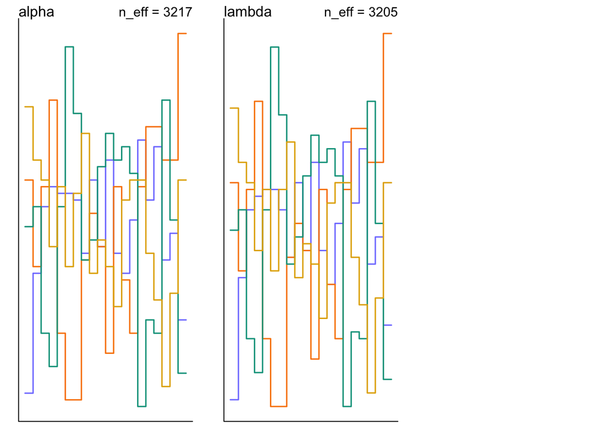

```r
trankplot(m0)
```

That’s what we like to see, all the chains mixing well after the initial phase.

Now lets create several more models, one with category as the predictor, another with technique as the predictor, and then finally using both category and technique as the predictor.

### Model 1

```r
m1 <- ulam(
  alist(
    tp ~ poisson(lambda),
    log(lambda) <- alpha + beta_category[category], # log link
    alpha ~ normal(0, 2.5),
    beta_category[category] ~ normal(0, 1)
  ), data = df, cores = 2, chains = 4, cmdstan = TRUE, log_lik = TRUE, iter = 5e3
)
```

again, check the diagnositcs

```r
precis(m1, depth = 2)
```

```
##                        mean        sd       5.5%    94.5%    n_eff    Rhat4
## alpha            1.40568704 0.7047395  0.2413482 2.507428 867.8995 1.008556
## beta_category[1] 0.18917509 0.7048383 -0.9191421 1.346709 870.8756 1.008549
## beta_category[2] 0.09027643 0.7041984 -1.0237077 1.247970 871.5246 1.008458
```

### Model 2

```r
m2 <- ulam(
  alist(
    tp ~ poisson(lambda),
    log(lambda) <- alpha + beta_technique[technique], # log link
    alpha ~ normal(0, 2.5),
    beta_technique[technique] ~ normal(0, 1)
  ), data = df, cores = 2, chains = 4, cmdstan = TRUE, log_lik = TRUE, iter = 5e3
)
```

Again, check the diagnostics

```r
precis(m2, depth = 3)
```

```
##                           mean        sd       5.5%    94.5%    n_eff    Rhat4
## alpha              1.499966413 0.6896423  0.4101998 2.680162 1121.016 1.004386
## beta_technique[1]  0.123623429 0.6897424 -1.0452016 1.219464 1116.781 1.004344
## beta_technique[2] -0.003965574 0.6893332 -1.1707526 1.087694 1119.838 1.004422
```

Again, `n_eff` is in the thousands and $\widehat{R} < 1.01$

### Model 3 (Final Model)

```r
m3 <- ulam(
  alist(
    tp ~ poisson(lambda),
    log(lambda) <- alpha + beta_category[category] + beta_technique[technique], # log link
    alpha ~ normal(0, 2.5),
    beta_category[category] ~ normal(0, 1),
    beta_technique[technique] ~ normal(0, 1)
  ), data = df, cores = 2, chains = 4, cmdstan = TRUE, log_lik = TRUE, iter = 5e3
)
```

For the final time, lets check the diagnostics

```r
precis(m3, depth = 4)
```

```
##                         mean        sd       5.5%    94.5%    n_eff    Rhat4
## alpha             1.32819363 0.9086265 -0.1324559 2.754518 2522.693 1.002263
## beta_category[1]  0.16531411 0.6797260 -0.8979593 1.253302 2423.017 1.001960
## beta_category[2]  0.06678619 0.6791556 -0.9853100 1.151447 2440.913 1.001874
## beta_technique[1] 0.16306855 0.6783381 -0.9142946 1.259843 2903.530 1.000846
## beta_technique[2] 0.03499653 0.6789566 -1.0415105 1.139757 2900.824 1.000855
```

Perfect, we have `n_eff` in the thousands and $\widehat{R} < 1.01$.

## Step 3: A Discussion of the Priors

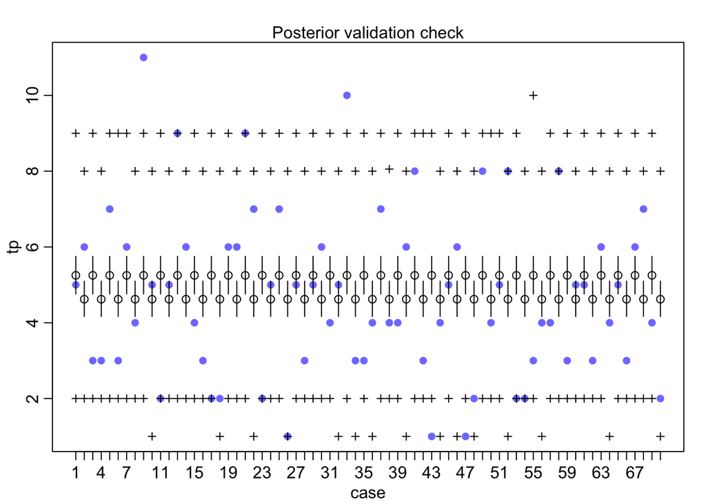

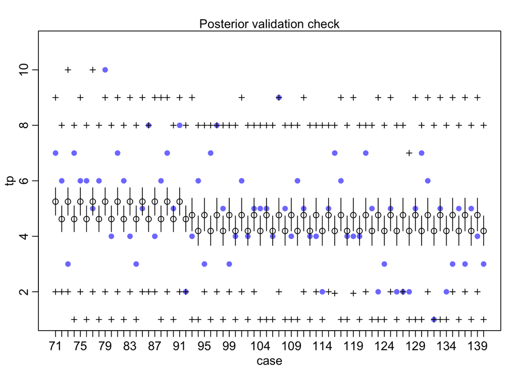

```r
postcheck(m3, window = 70)
```

So it seems that our model is not perfect, but we don’t want it to be anyways as this would cause over fitting. It seems like model 3 is reasonable and that our priors are also reasonable. Lets us see what happens when we change them to the default prior of $\mathsf{Normal}(0,10)$.

```r
m3_changed <- ulam(
  alist(
    tp ~ poisson(lambda),
    log(lambda) <- alpha + beta_category[category] + beta_technique[technique], # log link
    alpha ~ normal(0, 10),
    beta_category[category] ~ normal(0, 10),
    beta_technique[technique] ~ normal(0, 10)
  ), data = df, cores = 2, chains = 4, cmdstan = TRUE, log_lik = TRUE, iter = 5e3
)
```

Let’s check the diagnostics now that we have changed the priors.

```r
precis(m3_changed, depth = 4)
```

```
##                        mean       sd       5.5%     94.5%    n_eff    Rhat4
## alpha             0.9741641 7.070720 -10.187379 12.194028 1777.041 1.000719
## beta_category[1]  0.3430257 5.973046  -9.169259  9.941478 1678.854 1.000413
## beta_category[2]  0.2459763 5.973266  -9.252625  9.884334 1681.933 1.000418
## beta_technique[1] 0.3389825 6.161553  -9.444005 10.111232 1609.441 1.000388
## beta_technique[2] 0.2110395 6.161649  -9.580296  9.999761 1608.578 1.000382
```

Seems like the default prior of $\mathsf{Normal}(0,10)$. would also work.

## Step 4: Comparing the models using `LOO`

Lets compare our models now

```r
(loo_est <- compare(m0, m1, m2, m3, func=LOO))
```

```
##        PSIS       SE     dPSIS      dSE     pPSIS    weight
## m2 590.5747 12.64474 0.0000000       NA 1.6458060 0.3397386
## m3 590.9809 12.45847 0.4061707 2.077540 2.3838901 0.2772976
## m0 591.5132 13.40058 0.9384246 2.988245 0.8401307 0.2125047
## m1 591.9541 13.15639 1.3793625 3.404966 1.6066848 0.1704591
```

Interestingly, m2 is considered the best model.

```r
loo_est[2,3] + c(-1,1) * loo_est[2,4] * 1.96
```

```
## [1] -3.665808  4.478149
```

This shows that model 3 crosses zero, which indicates that there is a zero effect from the adding in `category` as a predictor.

## Step 5: Interpret Results

Based on the usage of the `compare()` function we select model 2 as our final model. The results of the `compare()` function indicate that using `technique` as our sole predictor (model 2) best explains our data. This suggests that `category` has little to no effect on the number of true positives `tp` found.

## Step 6: Causal Model (DAG)

Below is the causal model used to model our assumptions

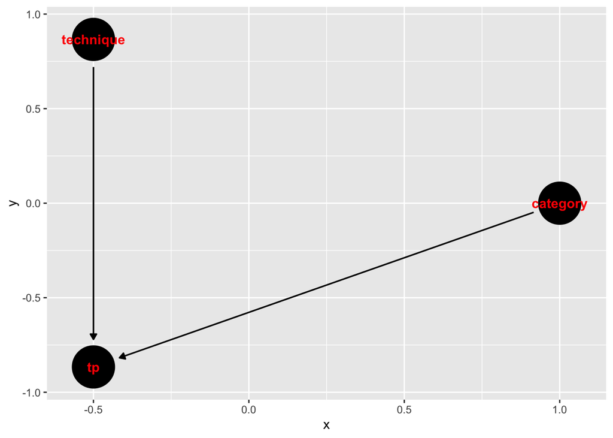

```r
dag <- dagitty("dag{category -> tp <- technique}")
ggdag(dag, layout = "circle", text_col = "red")
```

## Step 7: Presentation of diagnostics from running Stan on the ‘final’ model

### R hat and Sample Size

```r
precis(m2, depth = 2)
```

```
##                           mean        sd       5.5%    94.5%    n_eff    Rhat4
## alpha              1.499966413 0.6896423  0.4101998 2.680162 1121.016 1.004386
## beta_technique[1]  0.123623429 0.6897424 -1.0452016 1.219464 1116.781 1.004344
## beta_technique[2] -0.003965574 0.6893332 -1.1707526 1.087694 1119.838 1.004422
```

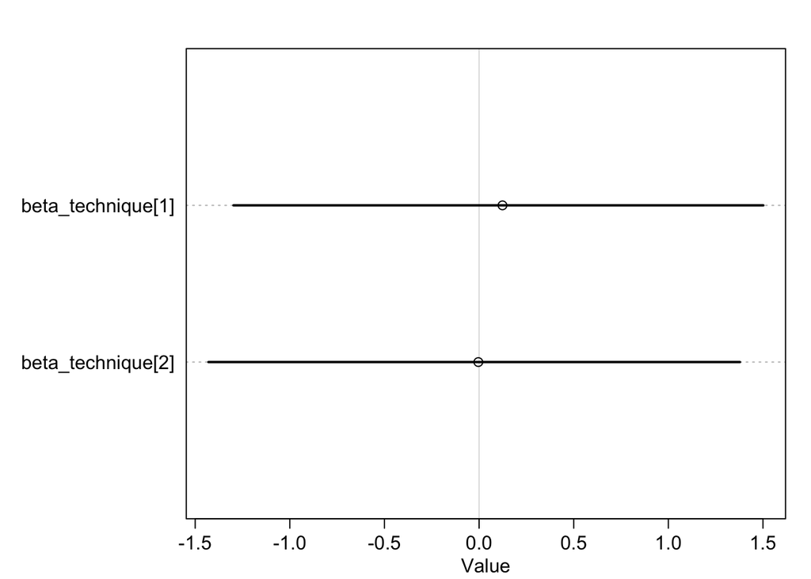

```r
plot(precis(m2, depth = 2, par = "beta_technique", prob = 0.95))
```